# Examen Series Temporales

Álvaro de Prada

2/2/2018

El Consejo de Administración de un Banco ha decido implementar un nueva linea de negocio, y desea crear un division de “Crédito para la Compra de Automoviles”. Las preocupaciones que tiene el Consejo, son sobre cuales serán las matriculaciones futuras de automoviles y desea que se realicen las predicciones mensuales para el año 2018 y 2019. Utiliza como mínimo modelos ETS y ARIMA. Los datos están en el fichero automoviles.csv. ¿Qué variable utilizarías para realizar un modelo de Función de Trasnferencia? ¿Y para un VAR?

En primer lugar cargaremos las librerías que emplearemos en el proceso de responder a la pregunta planteada:

```r
library(forecast)
```

```r
library(plotly)
library(moments)
library(ggfortify)
library(readr)
library(gridExtra)
library(ggplot2)
library(quantmod)
library(ggthemes)
```

A continuación cargamos el dataset que contiene los datos que emplearemos:

```r
library(readr)
automoviles <- read_delim("automoviles.csv",
    ";", escape_double = FALSE, col_types = cols(Unidades = col_number(),
        Year = col_integer()), trim_ws = TRUE)
```

Y hacemos un summary para tener una visión general de los datos:

```r
summary(automoviles)
```

```
##       Year          Mes               Unidades
##  Min.   :1993   Length:300         Min.   : 17432
##  1st Qu.:1999   Class :character   1st Qu.: 48921
##  Median :2005   Mode  :character   Median : 79187
##  Mean   :2005                      Mean   : 85644
##  3rd Qu.:2011                      3rd Qu.:119260
##  Max.   :2017                      Max.   :176980
```

En este punto podemos compobar que los datos no contienen NAs.

```r
str(automoviles)
```

```
## Classes 'tbl_df', 'tbl' and 'data.frame':    300 obs. of  3 variables:
##  $ Year    : int  1993 1993 1993 1993 1993 1993 1993 1993 1993 1993 ...
##  $ Mes     : chr  "Ene" "Feb" "Mar" "Abr" ...
##  $ Unidades: num  43815 61525 78924 69186 71355 ...
##  - attr(*, "spec")=List of 2
##   ..$ cols   :List of 3
##   .. ..$ Year    : list()
##   .. .. ..- attr(*, "class")= chr  "collector_integer" "collector"
##   .. ..$ Mes     : list()
##   .. .. ..- attr(*, "class")= chr  "collector_character" "collector"
##   .. ..$ Unidades: list()
##   .. .. ..- attr(*, "class")= chr  "collector_number" "collector"
##   ..$ default: list()
##   .. ..- attr(*, "class")= chr  "collector_guess" "collector"
##   ..- attr(*, "class")= chr "col_spec"
```

Nos quedamos unicamente con la columna de las matriculaciones

```r
automoviles.formato <- automoviles[3]
```

Convertimos los datos a , partiendo de la fecha de 1993 ya que nuestro dataset empieza en el enero de 1993, y especificamos que es mensual:

```r
date <-seq(as.Date("1993/01/01"), as.Date("2017/12/01"),"month")
date <- as.yearmon(date, "%Y%m")
matriculaciones<- zoo(automoviles.formato, date)

colnames(matriculaciones)<-c("Matriculaciones")

head(matriculaciones)
```

```
##          Matriculaciones
## ene 1993           43815
## feb 1993           61525
## mar 1993           78924
## abr 1993           69186
## may 1993           71355
## jun 1993           80037
```

A continuación representamos gráficamente los datos anteriores (ventas),

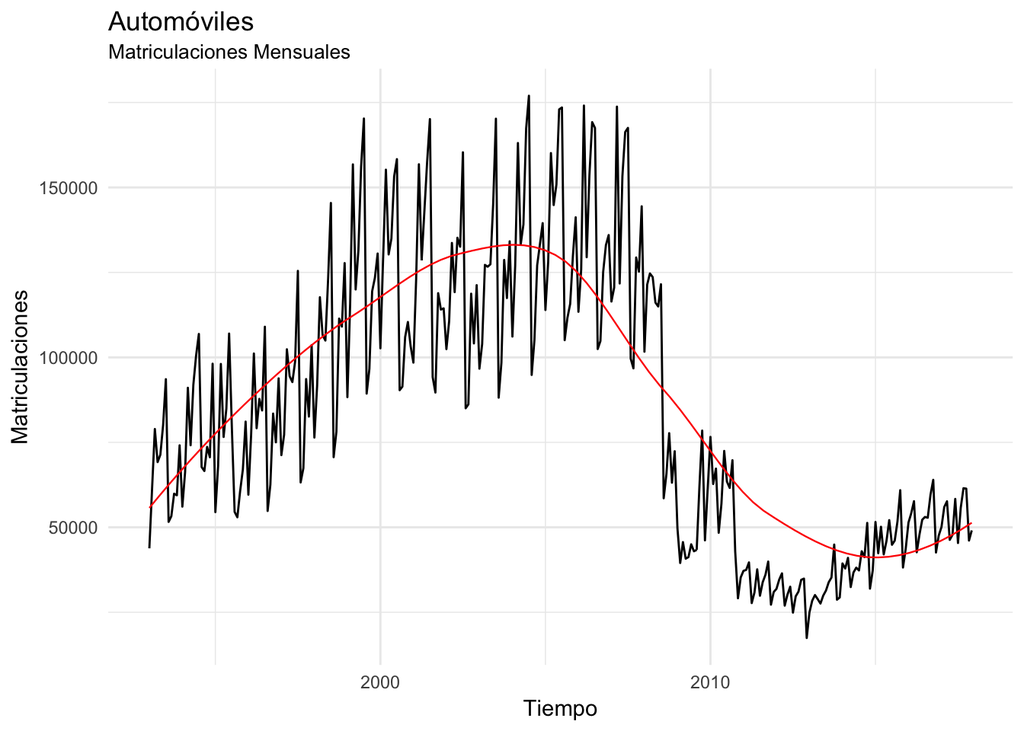

```r
matriculaciones.plot <- autoplot(matriculaciones) +
  labs(y="Matriculaciones",x="Tiempo")+
  ggtitle("Automóviles", subtitle ="Matriculaciones Mensuales") +
  theme_minimal() +
  geom_smooth(aes(y=(matriculaciones)),method = loess,span=0.35,se=F,size=0.4,col="red")
matriculaciones.plot
```

En la gráfica podemos observar que hasta el año 2008 aproximadamente, las ventas van en aumento. A partir de este punto las ventas caen en picado hasta que en el periodo 2013 aproximadamente vuelven a iniciar una tendencia alcista. Esto está directamente relacionado con la crisis vivida, la cual produjo un descenso drástico del número de matriculaciones

A continuación creamos un nuevo dataset que omita los 24 últimos periodos:

```r
omitido=24
longitud=length(matriculaciones)
totalMatriculaciones <- window(matriculaciones,start=index(matriculaciones),end=index(matriculaciones[longitud-omitido]))
```

Y procedemos a crear los modelos de predicción ETS y HW (Holt-Winters):

```r
ets1 <- ets(totalMatriculaciones)
ets2 <- ets(totalMatriculaciones,damped=T)
ets3 <- ets(totalMatriculaciones, allow.multiplicative.trend=T)
hw4 <- hw(totalMatriculaciones,seasonal="additive")
hw5 <- hw(totalMatriculaciones,seasonal="multiplicative")
hw6 <- hw(totalMatriculaciones,seasonal = "additive",damped = T)
hw7 <- hw(totalMatriculaciones,seasonal = "multiplicative",damped = T)
```

Construimos el DataFrame con los modelos anteriores:

```r
totalMatriculaciones.df <- data.frame(totalMatriculaciones,
                            ets1$fitted,
                            ets2$fitted,
                            ets3$fitted,
                            hw4$fitted,
                            hw5$fitted,
                            hw6$fitted,
                            hw7$fitted)
```

```r
#quitamos los últimos 2 años de la secuencia de fechas:
date <- seq(as.Date("1993/01/01"), as.Date("2015/12/01"),"month")
date <- as.yearmon(date, "%Y%m")
matriculaciones.fit <- zoo(totalMatriculaciones.df, order.by = date)
```

Definimos nuestra gráfica:

```r
etsfits <- autoplot(matriculaciones.fit, facet=NULL) +
  labs(y="Matriculaciones",x="Tiempo") +
  ggtitle("Visualización de modelo ETS y H-T en matriculaciones de vehículos") +
  theme_minimal() +
  scale_color_economist(labels=c("Original",
                                 "ETS(M,A,M)",
                                 "ETS (M,Ad,M)",
                                 "ETS (M,Md,M)",
                                 "H-W' método aditivo",
                                 "HW' método multipicativo",
                                 "Damped H-W' método aditivo",
                                 "Damped H-W' método multiplicativo"
)) + theme(legend.position = "bottom")
```

Y la llamamos:

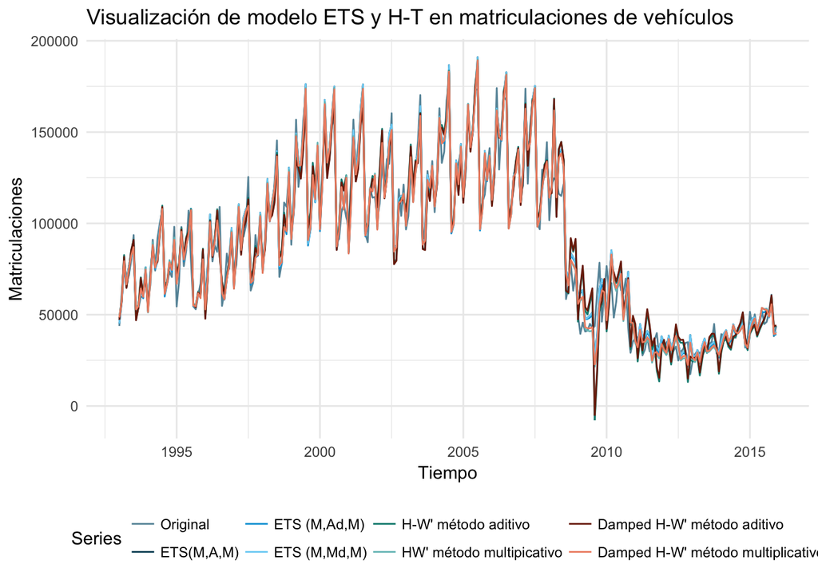

```r
etsfits
```

A simple vista, en la grafica se ve como todos los modelos estiman de forma similar existiendo pequeñas diferencias. A continuación vamos a calcular los errores de cada modelo para averiguar cual de todos ellos predice mejor:

```r
e1=forecast(ets1)
e2=forecast(ets2)
e3=forecast(ets3)
e4=forecast(hw4)
e5=forecast(hw5)
e6=forecast(hw6)
e7=forecast(hw7)
```

Y comprobamos la precisión de las predicciones definidas en el anterior chunk:

```r
accuracy(e1)
```

```
##                     ME     RMSE      MAE       MPE     MAPE      MASE
## Training set -2031.509 9402.566 7083.889 -3.899188 10.13223 0.5213716
##                    ACF1
## Training set -0.1153537
```

```r
accuracy(e2)
```

```
##                     ME     RMSE     MAE       MPE     MAPE      MASE
## Training set -518.4721 9097.131 6776.61 -1.819395 9.578144 0.4987559
##                     ACF1
## Training set -0.07107843
```

```r
accuracy(e3)
```

```
##                     ME     RMSE      MAE       MPE     MAPE      MASE
## Training set -2031.509 9402.566 7083.889 -3.899188 10.13223 0.5213716
##                    ACF1
## Training set -0.1153537
```

```r
accuracy(hw4)
```

```
##                     ME     RMSE      MAE       MPE     MAPE      MASE
## Training set -824.3432 11085.25 8127.018 -1.354403 11.79496 0.5981455
##                   ACF1
## Training set 0.1084369
```

```r
accuracy(hw5)
```

```
##                     ME     RMSE      MAE        MPE     MAPE      MASE
## Training set -362.9824 9025.589 6685.797 -0.7095157 9.339969 0.4920721
##                     ACF1
## Training set -0.03707742
```

```r
accuracy(hw6)
```

```
##                     ME     RMSE      MAE       MPE     MAPE      MASE
## Training set -557.8319 11000.12 8071.153 -1.819933 11.73185 0.5940338
##                   ACF1
## Training set 0.1034609
```

```r
accuracy(hw7)
```

```
##                     ME     RMSE      MAE       MPE     MAPE      MASE
## Training set -369.4643 8989.695 6626.872 -1.195132 9.296185 0.4877353
##                     ACF1
## Training set -0.04830749
```

Leyenda de los resultados obtenidos: ME: Mean Error||RMSE: Root Mean Squared Error||MAE: Mean Absolute Error||MPE: Mean Percentage Error||MAPE: Mean Absolute Percentage Error||MASE: Mean Absolute Scaled Error||ACF1: Autocorrelation of errors at lag 1

Asumiremos que el modelo con menor RMSE puede ser el que mejor prediga. En este caso comprobamos que ese modelo se trata del 7, correspondiente un holt winters con seasonal multiplicativo.

Por ello procederemos a realizar un summary sobre dicho modelo:

```r
summary(hw7)
```

```
##
## Forecast method: Damped Holt-Winters' multiplicative method
##
## Model Information:
## Damped Holt-Winters' multiplicative method
##
## Call:
##  hw(y = totalMatriculaciones, seasonal = "multiplicative", damped = T)
##
##   Smoothing parameters:
##     alpha = 0.4469
##     beta  = 0.0254
##     gamma = 0.2615
##     phi   = 0.9648
##
##   Initial states:
##     l = 62326.7255
##     b = 1121.0506
##     s=1.0848 0.8734 0.9196 0.7789 0.7563 1.3022
##            1.2326 1.1089 1.0196 1.2279 0.9317 0.7641
##
##   sigma:  0.1489
##
##      AIC     AICc      BIC
## 6752.601 6755.262 6817.768
##
## Error measures:
##                     ME     RMSE      MAE       MPE     MAPE      MASE
## Training set -369.4643 8989.695 6626.872 -1.195132 9.296185 0.4877353
##                     ACF1
## Training set -0.04830749
##
## Forecasts:
##          Point Forecast    Lo 80     Hi 80      Lo 95     Hi 95
## Jan 2016       50517.78 40875.17  60160.40 35770.6770  65264.89
## Feb 2016       45918.05 36216.22  55619.88 31080.3861  60755.72
## Mar 2016       51268.57 39392.18  63144.95 33105.2048  69431.93
## Apr 2016       42769.24 31991.47  53547.00 26286.0673  59252.40
## May 2016       47285.03 34407.16  60162.90 27590.0291  66980.03
## Jun 2016       54341.55 38435.62  70247.49 30015.5240  78667.58
## Jul 2016       52283.44 35914.75  68652.14 27249.6871  77317.20
## Aug 2016       56122.90 37407.72  74838.09 27500.4927  84745.32
## Sep 2016       58128.48 37557.96  78698.99 26668.5823  89588.37
## Oct 2016       65212.02 40802.28  89621.77 27880.5395 102543.51
## Nov 2016       42791.37 25898.70  59684.03 16956.2649  68626.47
## Dec 2016       45403.24 26549.84  64256.65 16569.4461  74237.04
## Jan 2017       53829.45 29400.20  78258.69 16468.1408  91190.75
## Feb 2017       48811.98 25690.81  71933.15 13451.2078  84172.75
## Mar 2017       54376.04 27535.41  81216.67 13326.8367  95425.24
## Apr 2017       45263.16 22015.11  68511.21  9708.3382  80817.99
## May 2017       49938.50 23286.46  76590.54  9177.7190  90699.28
## Jun 2017       57277.16 25554.80  88999.51  8762.0034 105792.31
## Jul 2017       55003.27 23429.05  86577.49  6714.6683 103291.87
## Aug 2017       58935.19 23909.81  93960.58  5368.4897 112501.89
## Sep 2017       60935.08 23483.19  98386.97  3657.3564 118212.80
## Oct 2017       68246.75 24910.80 111582.70  1970.1324 134523.37
## Nov 2017       44711.25 15407.00  74015.49  -105.7367  89528.23
## Dec 2017       47367.75 15352.62  79382.87 -1595.1631  96330.66
```

Comprobamos los residuos, donde podemos ver que no hay white noise (generalmente los residuos sí tienen white noise, mientras que el modelo no).

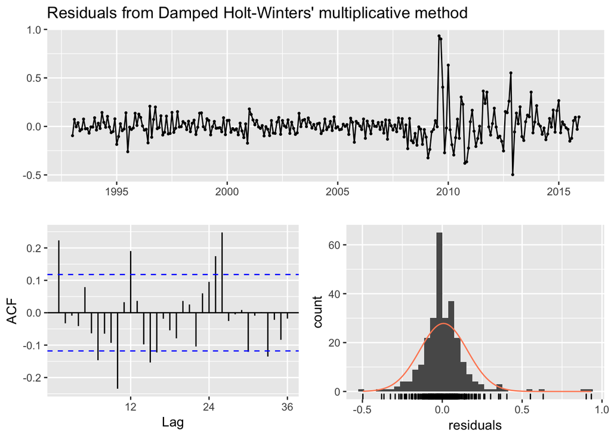

```
##
##  Ljung-Box test
##
## data:  Residuals from Damped Holt-Winters' multiplicative method
## Q* = 79.3, df = 7, p-value = 1.91e-14
##
## Model df: 17.   Total lags used: 24
```

```r
checkresiduals(hw7)
```

A continuación realizamos la gráfica de este modelo comparando en ella las matriculaciones reales contra la predicción del modelo:

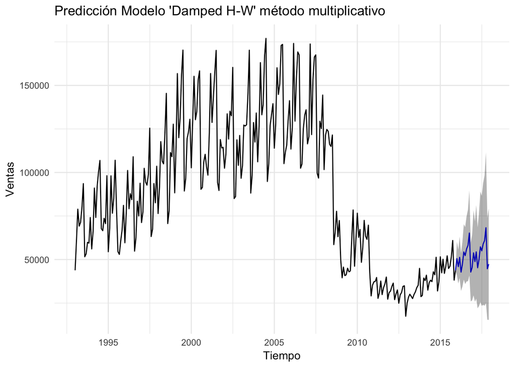

```r
e7 = forecast(hw7)
plotets <- autoplot(e7)+
labs(y="Ventas",x="Tiempo")+
  ggtitle("Predicción Modelo 'Damped H-W' método multiplicativo")+
  theme_minimal()+
  scale_colour_economist()+
  theme(legend.position = "bottom")
plotets
```

# Modelo ARIMA:

A continuación realizaremos el mismo analisis predictivo utilizando el modelo ARIMA. El modelo ARIMA precisa que los residuos no sean predecibles, es decir, que sean totalmente aleatorios.

En el siguiente chunk ejecutamos la funcion de autocorrelación sobre las ventas totales:

[figure not shown]

```r
acf(diff(totalMatriculaciones))
```

Y la autocorrelación parcial:

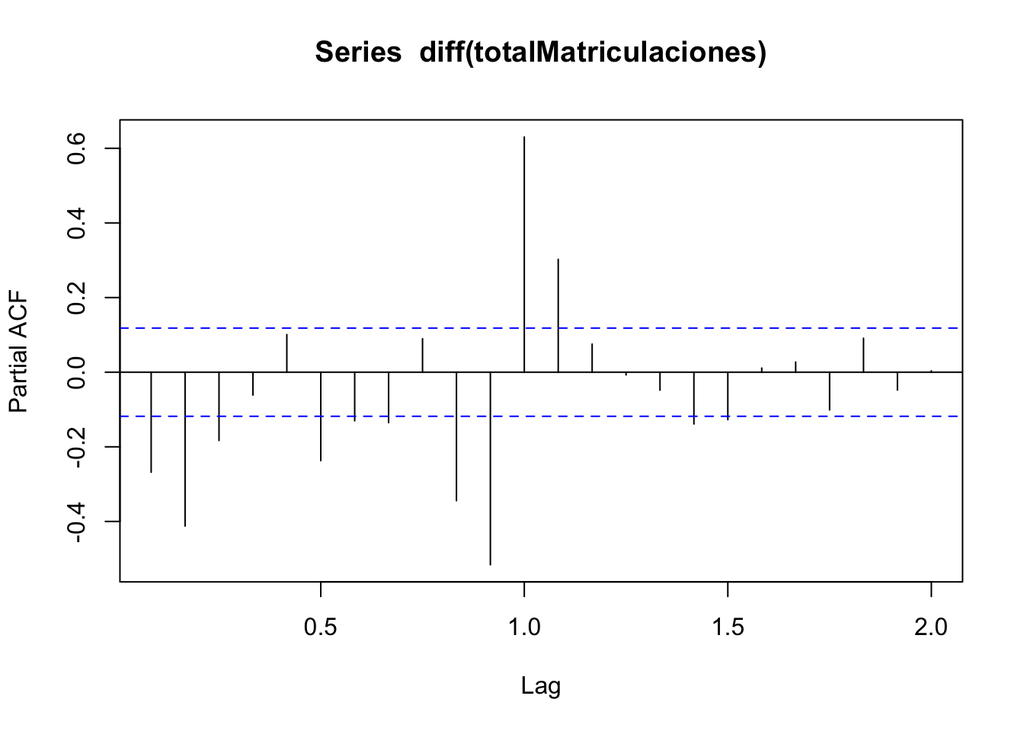

```r
pacf(diff(totalMatriculaciones))
```

Procedemos a elaborar los modelos ARIMA:

```r
arima1 <- auto.arima(totalMatriculaciones, approximation = F)
arima2 <- auto.arima(totalMatriculaciones,lambda=0, approximation = F)
arima3 <- auto.arima(totalMatriculaciones, lambda=0, approximation = F,stepwise = F)
arima4 <- auto.arima(totalMatriculaciones,approximation = F,stepwise = F)
```

Y ejecutamos Box.text para los 4 modelos, que nos ayudará a comprobar si los residuos son realmente aleatorios:

```r
Box.test(arima1$residuals,lag=12, fitdf=3, type="Lj")
```

```
##
##  Box-Ljung test
##
## data:  arima1$residuals
## X-squared = 20.073, df = 9, p-value = 0.01747
```

```r
Box.test(arima2$residuals,lag=12, fitdf=3, type="Lj")
```

```
##
##  Box-Ljung test
##
## data:  arima2$residuals
## X-squared = 22.726, df = 9, p-value = 0.006841
```

```r
Box.test(arima3$residuals,lag=12, fitdf=3, type="Lj")
```

```
##
##  Box-Ljung test
##
## data:  arima3$residuals
## X-squared = 21.172, df = 9, p-value = 0.01191
```

```r
Box.test(arima4$residuals,lag=12, fitdf=3, type="Lj")
```

```
##
##  Box-Ljung test
##
## data:  arima4$residuals
## X-squared = 16.399, df = 9, p-value = 0.059
```

Tras descartar los tres primeros modelos, procederemos a hacer la predición del cuarto modelo, el cual tiene un p-valor de 0,059:

```r
e2.4=forecast(arima4)
accuracy(e2.4)
```

```
##                    ME     RMSE     MAE        MPE     MAPE      MASE
## Training set 20.88575 10784.88 7870.12 -0.7165623 10.93902 0.5792379
##                     ACF1
## Training set 0.006404908
```

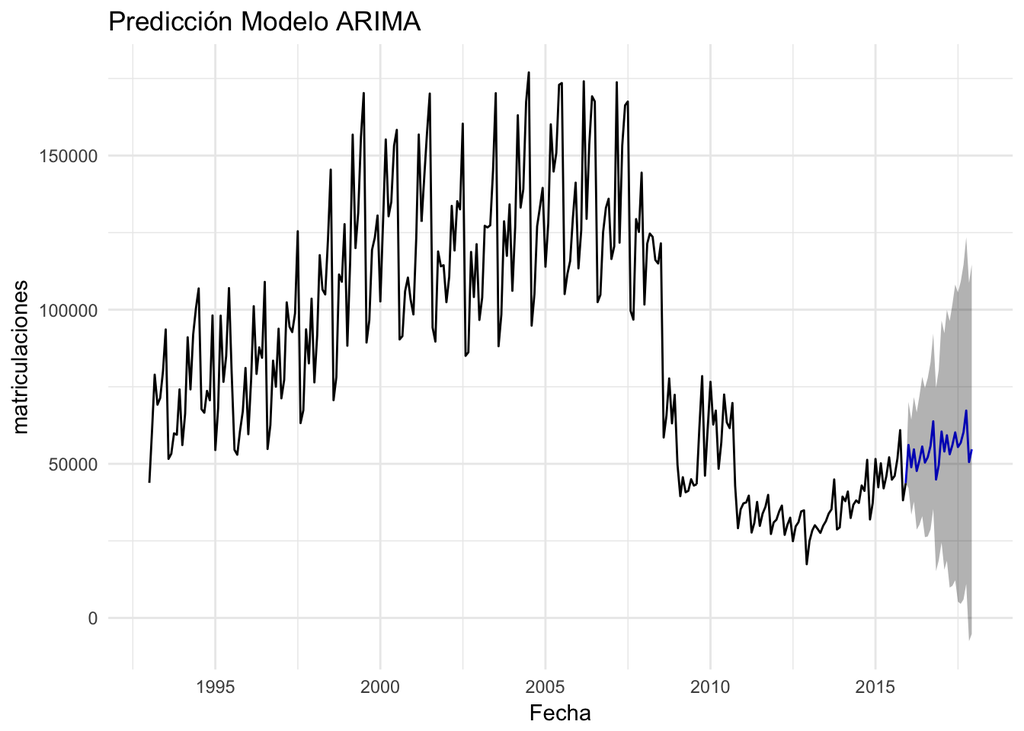

```r
plotarima <- autoplot(e2.4)+
  labs(y="matriculaciones",x="Fecha")+
  ggtitle("Predicción Modelo ARIMA")+
  theme_minimal()+
  scale_color_economist()+
  theme(legend.position = "bottom")
plotarima
```

# Comparación ETS y ARIMA

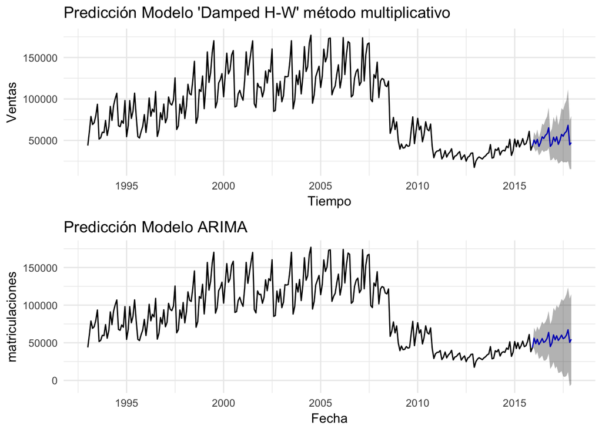

```r
grid.arrange(plotets,plotarima,ncol=1)
```

Podemos ver que los gráficos de ambos modelos se ajustan en buena medida a la realidad. Por ello, ambos modelos podrían ser válidos para predecir los años posteriores en cuanto a las matriculaciones de los vehículos. Sin embargo, vamos a elegir aquel que parece haber dado unas predicciones más precisas sobre los años que ya conocíamos. Aparentemente el modelo que más parece ajustarse en las gráficas es el ETS. Lo comproobaremos comparando el Root Mean Square Error (RMSE) de ambos modelos:

```r
accuracy(hw7) #ETS
```

```
##                     ME     RMSE      MAE       MPE     MAPE      MASE
## Training set -369.4643 8989.695 6626.872 -1.195132 9.296185 0.4877353
##                     ACF1
## Training set -0.04830749
```

El modelo ETS Damped Holt-Winters Multiplicative tiene un RMSE de 8989.695.

```r
accuracy(e2.4) #ARIMA
```

```
##                    ME     RMSE     MAE        MPE     MAPE      MASE
## Training set 20.88575 10784.88 7870.12 -0.7165623 10.93902 0.5792379
##                     ACF1
## Training set 0.006404908
```

El modelo ARIMA tiene un RMSE de 10784.88. Por lo tanto el modelo ETS con menor RMSE parece ser el que mejores resultados de predicción ha dado.

Es por ello que llevaremos a cabo la predicción de los 2 siguientes años (2018 y 2019) con el modelo ETS.

# Pronóstico de matriculaciones en 2018 y 2019. Modelo ETS Damped Holt-Winters Multiplicative.

Para llevar a cabo la predicción de los dos próximos años lo primero que necesitamos es emplear el dataset original con el total de matriculaciones. Esta vez no quitaremos periodos ya que queremos hacer pronósticos sobre años que no aparecen en el. Por lo tanto el modelo además tendrá más datos con los que entrenarse. A continuación creamos el modelo sobre el total de matriculaciones:

```r
hwFINAL <- hw(matriculaciones, seasonal = "multiplicative", damped = T)
```

Procedemos a hacer el forecast del modelo, indicándoles que el número de periodos a sobre los que hacer el forecast es de 24, siendo el equivalente a 2 años.

```r
fFINAL <- forecast(hwFINAL, h = 24)
accuracy(fFINAL)
```

```
##                     ME     RMSE      MAE       MPE     MAPE      MASE
## Training set -360.5167 8699.521 6341.296 -1.099148 9.029124 0.4967667
##                     ACF1
## Training set -0.03866349
```

Al emplear la función accuracy sobre la predicción obtenemos un RMSE 8699.521, menos que en los forecast realizados con los anteriores modelos. Procedemos por último a visualizar este forecast:

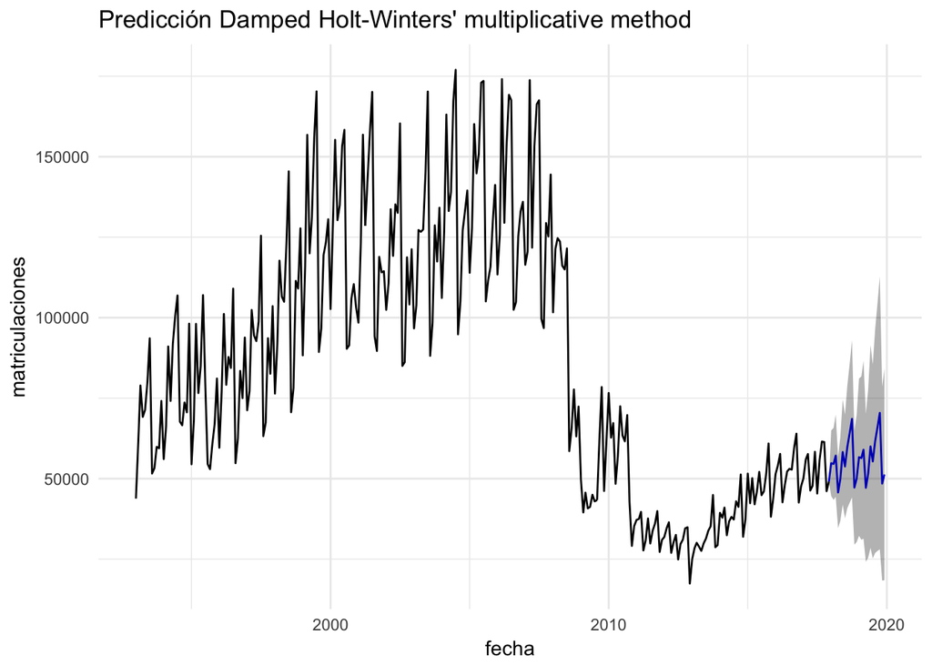

```r
plotFINALets <- autoplot(fFINAL)+
  labs(y = "matriculaciones",x="fecha")+
  ggtitle("Predicción Damped Holt-Winters' multiplicative method")+
  theme_minimal()+
  scale_colour_economist()+
  theme(legend.position = "bottom")
plotFINALets
```

# Conclusión:

En primer lugar hemos analizado los datos y hemos comprobado que existe un fuerte bajón el cual está vinculado a la crisis financiera, que redujo de forma sustancial las matriculaciones de vehículos. Actualmente nos encontramos en un proceso de recuperación y esto se muestra en los datos en donde podemos ver que vuelve a producirse una tendencia alcista.

Finalmente, respondiendo a la pregunta de negocio:

¿Cúales serán las matriculaciones futuras de automoviles para el año 2018 y 2019? Hemos obtenido a través del modelo ETS el siguiente gráfico con los posibles comportamientos que pueden tomar las matriculaciones en los próximos 2 años. Podemos observar que el forecast presenta una cierta horizontalidad en el número de matriculaciones, no siendo claramente visible ni una tendencia alcista ni una bajista. Por lo tanto concluimos afirmando que los forecast producidos por el modelo de series temporales que mejores resultados ha mostrado, muestra una consolidación de la horizontalidad vivida en el último año, y la prolonga hasta 2019.

# Preguntas adicionales:

## ¿Qué variable utilizarías para realizar un modelo de Función de Trasnferencia? ¿Y para un VAR?

Las funciones de transferencia permiten especificar la manera en que los valores pasados de las variables independientes (predictor) se utilizan para pronosticar valores futuros de la serie dependiente. Para realizar un modelo de Función de transferencia sobre el modelo de arima podríamos emplear la función ‘arima’ o ‘arimax’ de la librería TSA. En dichas funciones se incluye la posibilidad de añadir función de transferencia al modelo a través de los parámetros ‘xtransf’ y ‘transfer’ de la función, en donde tendríamos que indicar los datos relativos a la función de transferencia.

Por otro lado, VAR o Vector Autoregressive model podríamos implementarlo a través de la función VAR() de la librería LPTime y que tiene la siguiente forma: VAR(y, p = 1, exogen = NULL), donde Y = Variable endógena para el modelo VAR, p = lag-order para el modelo autorregresivo, y exogen = Variable exógena para el modelo VAR.